# Final Exam

Aarushi Gupta SID 905-328-941

Stats 20 Section 1

```r
library(readr)
library(dplyr)
library(DT)
library(tidyverse)
library(ggplot2)
library(forcats)
```

## 1.

```r
# First, we load the data into R.
load(file = "FinalData.rdata")

# Then, we combine the CrimesA and CrimesB datasets using the inner_join() function.
dfA <- as.data.frame(CrimesA)
dfB <- as.data.frame(CrimesB)
crimes <- inner_join(dfA, dfB, by = "Id.Number")
```

> There are `275,517` observations and `17` variables available in the combined dataset (crimes) consisting of CrimesA and CrimesB.

## 2.

```r
# First, we calculate the proportion of all crimes that resulted in an arrest.
(sum(crimes$arrest == 'TRUE'))/(nrow(crimes))
```

```
## [1] 0.2888315
```

```r
# Then, we calculate the proportion of crimes that resulted in an arrest for each ward.
ward_crime <- crimes[c(11, 15)] %>% group_by(ward) %>% summarize(t_crime = sum(n()))
ward_arrests <- crimes[c(11, 15)] %>% group_by(ward) %>% summarize(t_arr = sum(arrest == 'TRUE'))
ward_data <- inner_join(ward_crime, ward_arrests, by = "ward") %>%
  mutate(prop_arr = (t_arr)/(t_crime)) %>% na.omit()

# Finally, we use a datatable to display the proportions.
datatable(ward_data)
```

|  | ward | t_crime | t_arr | prop_arr |
| --- | --- | --- | --- | --- |
| 1 | 1 | 4653 | 719 | 0.154523963034601 |
| 2 | 2 | 10866 | 3041 | 0.279863795324867 |
| 3 | 3 | 7291 | 2210 | 0.303113427513373 |
| 4 | 4 | 4610 | 869 | 0.188503253796095 |
| 5 | 5 | 6495 | 1649 | 0.253887605850654 |
| 6 | 6 | 8808 | 2524 | 0.286557674841054 |
| 7 | 7 | 7810 | 2298 | 0.294238156209987 |
| 8 | 8 | 7978 | 2020 | 0.253196289796942 |
| 9 | 9 | 7210 | 2196 | 0.304576976421637 |
| 10 | 10 | 5043 | 1579 | 0.313107277414238 |

[output cut: 40 more lines]

Approximately `0.289` or `28.9%` of all crimes resulted in an arrest. This proportion varies significantly by ward, with some having a smaller proportion of crimes resulting in an arrest and others having a greater proportion of crimes resulting in an arrest.

## 3.

```r
# First, we create the new column for Part 1 by filtering for the specified crimes.
crimes <- crimes %>% mutate(PARTONE = primary.type == "arson" | primary.type == "burglary" |
                              primary.type == "crim sexual assault" | primary.type == "criminal sexual assault" |
                              primary.type == "homicide" | primary.type == "motor vehicle theft" |
                              (grepl("aggravated|agg", description, ignore.case = TRUE) &
                                 grepl("assault|asslt", description, ignore.case = TRUE)))

# Then, we calculate the proportion of Part 1 crimes for each ward.
p1 <- crimes[c(15, 18)] %>% group_by(ward) %>% summarize(t_p1 = sum(PARTONE == 'TRUE'))
ward_p1 <- inner_join(ward_crime, p1, by = "ward") %>%
  mutate(prop_p1 = (t_p1)/(t_crime)) %>% na.omit()

# Finally, we display the proportions in decreasing order using a datatable.
datatable(ward_p1[rev(order(ward_p1$prop_p1)),])
```

|  | ward | t_crime | t_p1 | prop_p1 |
| --- | --- | --- | --- | --- |
| 1 | 14 | 3908 | 564 | 0.14431934493347 |
| 2 | 39 | 2460 | 349 | 0.141869918699187 |
| 3 | 38 | 2821 | 387 | 0.137185395249911 |
| 4 | 31 | 3846 | 526 | 0.136765470618825 |
| 5 | 26 | 4000 | 535 | 0.13375 |
| 6 | 1 | 4653 | 620 | 0.13324736728992 |
| 7 | 32 | 4490 | 597 | 0.132962138084633 |
| 8 | 23 | 3132 | 411 | 0.131226053639847 |
| 9 | 35 | 3245 | 421 | 0.129738058551618 |
| 10 | 50 | 2799 | 353 | 0.126116470167917 |

[output cut: 40 more lines]

## 4.

```r
# First, we extract the date and arrest (crime) variables from crimes, making sure to extract only the month from the date variable.
date <- crimes[c(2, 11)] %>% mutate(CRIME_DATE = substring(CRIME_DATE, 1, 2)) %>%
  mutate(CRIME_DATE = as.numeric(CRIME_DATE))

# Then, we calculate the total number of crimes committed per month. We also change the month numbers into month abbreviations and rename the data columns.
crime_m <- date %>% group_by(CRIME_DATE) %>% summarize(tot_crime = sum(n()))
crime_m$CRIME_DATE <- (month.abb[crime_m$CRIME_DATE])
colnames(crime_m) = c("Month", "Total Crimes")

# Finally, we display the data in a datatable and a connected scatterplot.
datatable(crime_m)
```

|  | Month | Total Crimes |
| --- | --- | --- |
| 1 | Jan | 20024 |
| 2 | Feb | 18026 |
| 3 | Mar | 22190 |
| 4 | Apr | 22916 |
| 5 | May | 24861 |
| 6 | Jun | 25438 |
| 7 | Jul | 26558 |
| 8 | Aug | 25880 |
| 9 | Sep | 23890 |
| 10 | Oct | 23990 |

[output cut: 2 more lines]

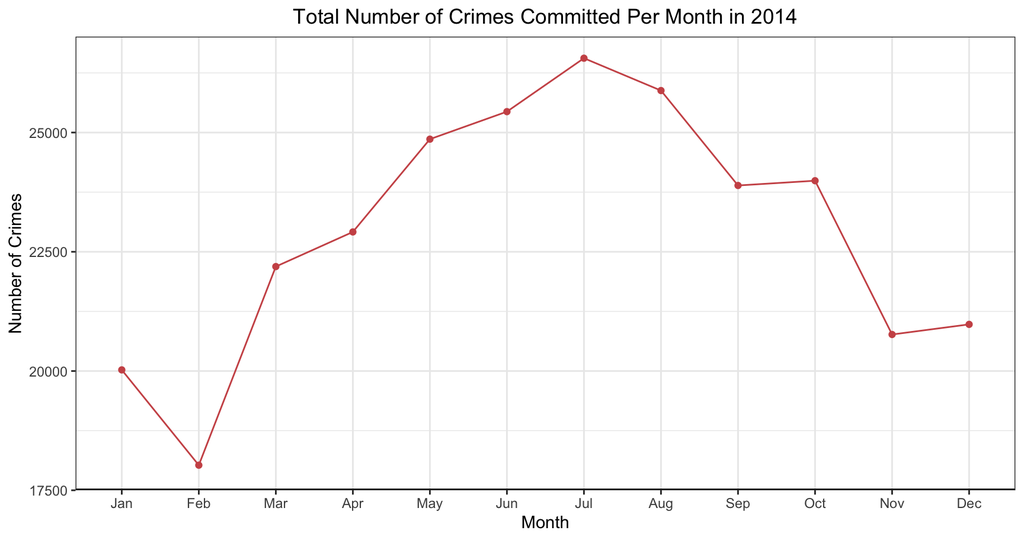

```r
 crime_m %>% ggplot(aes(x = factor(Month, level = c("Jan", "Feb", "Mar", "Apr", "May", "Jun",
                                                     "Jul", "Aug", "Sep", "Oct", "Nov", "Dec")),
                         y = `Total Crimes`, group = 1)) +
  geom_point(color = "indianred3") + geom_line(color = "indianred3") +
  ggtitle("Total Number of Crimes Committed Per Month in 2014") +
  labs(x = "Month", y = "Number of Crimes") +
  geom_hline(yintercept = 17500, size = 1, colour = "black") +
  scale_y_continuous(expand = expansion(mult = c(0, 0.05))) +
  theme_bw() +
  theme(plot.title = element_text(hjust = 0.5))
```

In this U.S. metropolitan city, more crimes are committed in June, July, and August than other months. In other words, there is a seasonality of crimes, where the number of crimes rises in the summer and decreases drastically in the winter. As shown throughout 2014, the number of crimes committed in this city hit a peak in July.

This is consistent with findings from the Justice Department and other agencies, who have found that as temperatures increase, crimes tend to also go up. However, the level of correlation between the two does vary depending on the type of crime committed (e.g. violent, non-violent, etc.), among other factors.

## 5.

```r
# First, we remove the de-identified numeric location from the block addresses.
street <- crimes[c(4, 5)] %>% mutate(block = substring(block, 7))

# Then, we identify the street with most crimes.
street_crime <- street %>% group_by(block) %>%
  summarize(t_crime = sum(n())) %>%
  filter(t_crime == max(t_crime))
street_crime
```

```
## # A tibble: 1 x 2
##   block          t_crime
##   <chr>            <int>
## 1 S MICHIGAN AVE    2938
```

```r
# Finally, we identify the street with the most homicides.
street_hom <- street %>% group_by(block) %>%
  summarize(t_hom = sum(primary.type == "homicide")) %>%
  filter(t_hom == max(t_hom))
street_hom
```

```
## # A tibble: 4 x 2
##   block         t_hom
##   <chr>         <int>
## 1 S INDIANA AVE     6
## 2 S LAFLIN ST       6
## 3 S MORGAN ST       6
## 4 W 63RD ST         6
```

1. The street with the most crimes is `S Michigan Avenue`.
2. The streets with the most homocides are `S Indiana Avenue`, `S Laflin Street`, `S Morgan Street`, and `W 63rd Street`.

## 6.

```r
# First, we set the correct seed and sample size.
set.seed(905328941)
crime_sample <- crimes[sample(1:nrow(crimes), size = 100),]
head(crime_sample)
```

```
##        Id.Number             CRIME_DATE case.number           primary.type
## 3978     9446840 01/01/2014 01:25:00 AM    HX100123            sex offense
## 14968    9469019 01/21/2014 10:35:00 AM    HX122200 public peace violation
## 65425    9562345 04/07/2014 11:20:00 AM    HX214125        criminal damage
## 135488   9680850 06/29/2014 12:00:00 AM    HX330876        criminal damage
## 21129    9480525 01/31/2014 06:00:00 AM    HX133807                  theft
## 92047    9608185 05/12/2014 09:00:00 AM    HX258313                battery
##                        block iucr domestic FBI_code     latitude     longitude
## 3978     039XX W POTOMAC AVE 1563     TRUE       17 41.904451678 -87.724618792
## 14968   040XX W JACKSON BLVD 0470    FALSE       24 41.877074265 -87.726534702
## 65425  108XX S GREEN BAY AVE 1310     TRUE       14 41.698462836 -87.541343712
## 135488 040XX W KAMERLING AVE 1310    FALSE       14 41.905361271   -87.7274498
## 21129   022XX W MARQUETTE RD 0810    FALSE       06 41.771994643 -87.680246709
## 92047        026XX W 64TH ST 0486     TRUE      08B 41.777273199 -87.690201936
##        arrest location.description             description community.area ward
## 3978    FALSE            residence   criminal sexual abuse             23   27
## 14968    TRUE                alley        reckless conduct             26   28
## 65425   FALSE             sidewalk             to property             52   10
## 135488  FALSE            residence             to property             23   27
## 21129   FALSE               street               over $500             66   15
## 92047   FALSE            apartment domestic battery simple             66   15
##        district beat PARTONE
## 3978        025 2535   FALSE
## 14968       011 1115   FALSE
## 65425       004 0432   FALSE
## 135488      025 2534   FALSE
## 21129       008 0832   FALSE
## 92047       008 0825   FALSE
```

```r
# Then, we calculate the proportion of crimes that resulted in arrests in the sample.
(sum(crime_sample$arrest == 'TRUE'))/(nrow(crime_sample))
```

```
## [1] 0.25
```

In my resulting sample, the proportion of crimes that resulted in arrests is `0.25` or `25%`.

## 7.

```r
# First, we filter out crimes that had less than 1000 crimes committed.
type_crime <- crimes[c(4, 11)] %>% group_by(`primary.type`) %>%
  mutate(tot_crime = sum(n())) %>%
  filter(tot_crime >= 1000) %>%

# Then, we calculate the proportion of crimes that resulted in arrests for each type of crime.
  mutate(tot_arr = sum(arrest == 'TRUE')) %>%
  mutate(prop = (tot_arr)/(tot_crime)) %>%
  select(-arrest, -tot_crime, -tot_arr) %>%
  unique()

# Finally, we order the proportion of arrests in decreasing order to display only the top 10 types of crime.
type_crime <- type_crime[rev(order(type_crime$prop)),]
head(type_crime, 10)
```

```
## # A tibble: 10 x 2
## # Groups:   primary.type [10]
##    primary.type                      prop
##    <fct>                            <dbl>
##  1 narcotics                        0.996
##  2 prostitution                     0.992
##  3 interference with public officer 0.946
##  4 weapons violation                0.829
##  5 public peace violation           0.809
##  6 criminal trespass                0.728
##  7 assault                          0.267
##  8 battery                          0.253
##  9 other offense                    0.245
## 10 offense involving children       0.185
```

The top 10 types of crime with at least 1,000 crimes that result in the highest proportion of arrests, in order from greatest to least, are: narcotics, prostitution, interference with a public officer, weapons violation, public peace violation, criminal trespass, assault, battery, other offense, and offense involving children.

## 8.

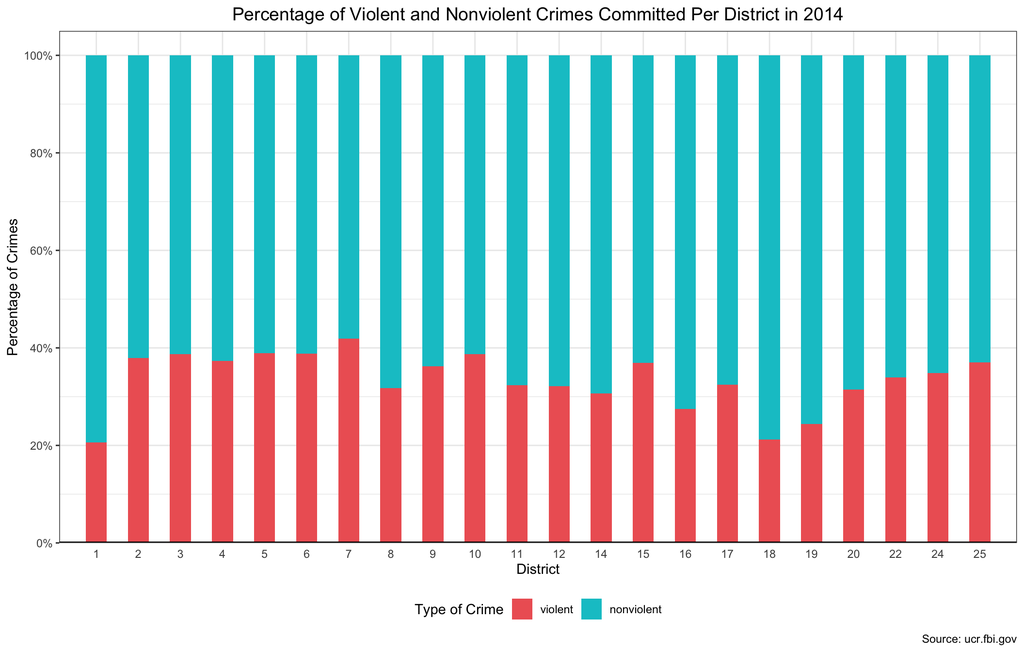

```r
# First, we extract the type of crime, arrest, and district variables from the dataset for further analysis.
dist <- crimes[c(4, 11, 16)]

# We classify the following types of crime as "violent" based on FBI Reporting criteria.
dist <- dist %>% mutate(`primary.type` = fct_recode(`primary.type`, "violent" = "arson", "violent" = "assault", "violent" = "robbery", "violent" = "battery", "violent" = "crim sexual assault", "violent" = "criminal sexual assault", "violent" = "homicide", "violent" = "human trafficking", "violent" = "kidnapping", "violent" = "interference with public officer", "violent" = "motor vehicle theft", "violent" = "offense involving children", "violent" = "stalking", "violent" = "sex offense"))

# We classify the following types of crime as "nonviolent" based on FBI Reporting criteria.
dist <- dist %>% mutate(`primary.type` = fct_recode(`primary.type`, "nonviolent" = "burglary", "nonviolent" = "concealed carry license violation", "nonviolent" = "criminal damage", "nonviolent" = "deceptive practice", "nonviolent" = "gambling", "nonviolent" = "non-criminal", "nonviolent" = "non - criminal", "nonviolent" = "non-criminal (subject specified)", "nonviolent" = "obscenity", "nonviolent" = "public indecency", "nonviolent" = "public peace violation", "nonviolent" = "prostitution", "nonviolent" = "criminal trespass", "nonviolent" = "theft", "nonviolent" = "weapons violation", "nonviolent" = "intimidation", "nonviolent" = "liquor law violation", "nonviolent" = "narcotics", "nonviolent" = "other narcotic violation", "nonviolent" = "other offense"))

# We create a table to calculate the number of crimes per type of crime per district.
distc <- table(dist$primary.type, crimes$district)

# We convert the table into a dataframe in order to use ggplot2.
distcrime.df <- as.data.frame(distc)
colnames(distcrime.df) <- c("Crime Type","District", "Count")

# Then, we extract the arrest and district variables from the crimes dataset to calculate the total number
# of crimes per district.
dist2 <- crimes[c(11, 16)] %>% group_by(district) %>%
  mutate(tot_crime = sum(n())) %>%
  select(-arrest) %>%
  unique()
colnames(dist2) <- c("District", "Total Crimes")

# We combine the datasets by district to calculate the percentage of each type of crime committed per district.
# We filter out District 31, since it has only 3 data points, and standardize the District notation.
crimedist.df <- inner_join(distcrime.df, dist2, by = "District") %>%
  mutate(Proportion = (Count/`Total Crimes`)) %>%
  filter(District != "031") %>%
  mutate(District = substring(District, 2)) %>%
  mutate(District = as.factor(as.numeric(as.character(District))))

# Finally, we create a stacked barplot to display the data.
crimedist.df %>% ggplot(aes(x = District, y = Proportion, fill = as.factor(`Crime Type`))) +
  geom_bar(stat = "identity", position = position_stack(reverse = TRUE), width = 0.5) +
  ggtitle("Percentage of Violent and Nonviolent Crimes Committed Per District in 2014") +
  labs (x = "District", y = "Percentage of Crimes", caption = "Source: ucr.fbi.gov") +
  geom_hline(yintercept = 0, size = 1, colour = "black") +
  scale_fill_manual(values = c("indianred2", "turquoise3"), name = "Type of Crime") +
  scale_y_continuous(expand = expansion(mult = c(0, 0.05)), breaks = seq(0, 1.00, 0.2),
                     labels = scales::percent) +
  scale_x_discrete(expand = c(0.04, 0.04)) +
  theme_bw() +
  theme(legend.position = "bottom", plot.title = element_text(size = 14, hjust = 0.5),
        axis.ticks.x = element_blank())
```

Using the original district, arrest, and type of crime variables in the dataset, I constructed a visualization displaying the percentage of violent and nonviolent crimes committed in each district in 2014. According to the FBI Uniform Crime Reporting Division, “violent” crimes are those that cause bodily harm or injury to another person, while “nonviolent” crimes are usually related to drugs, public discipline, and property and don’t involve attacking a victim.